# ModelEvaluationR

Mike Delevan

```r
library(tidyverse)
library(broom)
library(caret)
library(boot)
library(tidyr)
library(fastR2)
library(ISLR)
library(ggplot2)
library(GGally)
library(e1071)
library(cutpointr)
library(gridExtra)
library(olsrr)
library(ROCR)
library(class)
```

```r
baseball_df <- read.csv(file="C:\\Users\\delevan\\PycharmProjects\\Senior-Project\\data-scraper\\combinedData.csv", header=TRUE, sep=",")

head(baseball_df)
```

|  | teamAbbr | League | Score | isHomeTeam | atBats | Hits | Doubles | Triples | homeRuns | RBI | Walks | Strikeouts | LOB | pitchersUsed | indER | teamER | Errors | battingAverage | OBP | Slugging | OPS | Win | wonPrev | WHIP | KPercent | BBPercent | FIP | BABIP | ERA | … |
| --- | --- | --- | --- | --- | --- | --- | --- | --- | --- | --- | --- | --- | --- | --- | --- | --- | --- | --- | --- | --- | --- | --- | --- | --- | --- | --- | --- | --- | --- | --- |
| 1 | CHN | NL | 5 | 0 | 30 | 5 | 1 | 0 | 2 | 5 | 3 | 7 | 1 | 6 | 14 | 14 | 2 | 0.1666667 | 0.2424242 | 0.4000000 | 0.6424242 | 0 | 0 | 2.500000 | 0.1739130 | 0.17391304 | 7.704000 | 0.4000000 | 15.75 | … |
| 2 | CHN | NL | 2 | 0 | 31 | 7 | 1 | 0 | 0 | 1 | 3 | 7 | 6 | 4 | 3 | 3 | 0 | 0.2258065 | 0.2857143 | 0.2580645 | 0.5437788 | 0 | 0 | 0.875000 | 0.3750000 | 0.06250000 | 2.829000 | 0.2500000 | 9.56 | … |
| 3 | CHN | NL | 2 | 0 | 30 | 4 | 0 | 0 | 2 | 2 | 3 | 9 | 5 | 5 | 0 | 0 | 1 | 0.1333333 | 0.2121212 | 0.3333333 | 0.5454545 | 1 | 0 | 1.333333 | 0.1081081 | 0.10810811 | 3.523444 | 0.2758621 | 6.12 | … |
| 4 | CHN | NL | 4 | 0 | 36 | 11 | 0 | 0 | 1 | 4 | 2 | 7 | 13 | 3 | 5 | 5 | 0 | 0.3055556 | 0.3809524 | 0.3888889 | 0.7698413 | 0 | 1 | 0.875000 | 0.1290323 | 0.06451613 | 4.454000 | 0.1666667 | 6.00 | … |
| 5 | CHN | NL | 4 | 0 | 30 | 5 | 0 | 0 | 3 | 4 | 1 | 8 | 0 | 3 | 3 | 3 | 1 | 0.1666667 | 0.1935484 | 0.4666667 | 0.6602151 | 1 | 0 | 1.000000 | 0.3714286 | 0.05714286 | 2.301222 | 0.3333333 | 5.36 | … |
| 6 | CHN | NL | 1 | 0 | 31 | 5 | 1 | 0 | 0 | 1 | 8 | 9 | 12 | 5 | 2 | 2 | 1 | 0.1612903 | 0.3333333 | 0.1935484 | 0.5268817 | 0 | 1 | 1.375000 | 0.2857143 | 0.11428571 | 2.079000 | 0.3333333 | 4.86 | … |

```r
NA
```

```r
summary(baseball_df)
```

```
    teamAbbr     League         Score         isHomeTeam      atBats           Hits           Doubles
 MIL    : 1459   AL:21371   Min.   : 0.00   Min.   :0.0   Min.   :16.00   Min.   : 0.000   Min.   : 0.000
 TEX    : 1459   NL:22329   1st Qu.: 2.00   1st Qu.:0.0   1st Qu.:31.00   1st Qu.: 6.000   1st Qu.: 1.000
 ANA    : 1458              Median : 4.00   Median :0.5   Median :33.00   Median : 8.000   Median : 1.000
 ARI    : 1458              Mean   : 4.34   Mean   :0.5   Mean   :34.07   Mean   : 8.648   Mean   : 1.707
 BAL    : 1458              3rd Qu.: 6.00   3rd Qu.:1.0   3rd Qu.:36.00   3rd Qu.:11.000   3rd Qu.: 2.000
 COL    : 1458              Max.   :25.00   Max.   :1.0   Max.   :76.00   Max.   :28.000   Max.   :11.000
 (Other):34950
    Triples          homeRuns          RBI             Walks          Strikeouts          LOB
 Min.   :0.0000   Min.   :0.000   Min.   : 0.000   Min.   : 0.000   Min.   : 0.000   Min.   : 0.000
 1st Qu.:0.0000   1st Qu.:0.000   1st Qu.: 2.000   1st Qu.: 2.000   1st Qu.: 6.000   1st Qu.: 5.000
 Median :0.0000   Median :1.000   Median : 4.000   Median : 3.000   Median : 8.000   Median : 7.000
 Mean   :0.1777   Mean   :1.033   Mean   : 4.132   Mean   : 3.083   Mean   : 7.707   Mean   : 6.857
 3rd Qu.:0.0000   3rd Qu.:2.000   3rd Qu.: 6.000   3rd Qu.: 4.000   3rd Qu.:10.000   3rd Qu.: 9.000
 Max.   :5.0000   Max.   :8.000   Max.   :25.000   Max.   :18.000   Max.   :26.000   Max.   :25.000

  pitchersUsed        indER            teamER       Errors      battingAverage        OBP
 Min.   : 1.000   Min.   : 0.000   Min.   : 0   Min.   :0.000   Min.   :0.0000   Min.   :0.0000
 1st Qu.: 3.000   1st Qu.: 2.000   1st Qu.: 2   1st Qu.:0.000   1st Qu.:0.1935   1st Qu.:0.2571
 Median : 4.000   Median : 4.000   Median : 3   Median :0.000   Median :0.2500   Median :0.3143
 Mean   : 4.053   Mean   : 4.007   Mean   : 4   Mean   :0.594   Mean   :0.2485   Mean   :0.3127
 3rd Qu.: 5.000   3rd Qu.: 6.000   3rd Qu.: 6   3rd Qu.:1.000   3rd Qu.:0.3030   3rd Qu.:0.3714
 Max.   :13.000   Max.   :25.000   Max.   :25   Max.   :7.000   Max.   :0.5714   Max.   :0.6034

    Slugging           OPS              Win         wonPrev            WHIP          KPercent
 Min.   :0.0000   Min.   :0.0000   Min.   :0.0   Min.   :0.0000   Min.   :0.000   Min.   :0.0000
 1st Qu.:0.2857   1st Qu.:0.5524   1st Qu.:0.0   1st Qu.:0.0000   1st Qu.:1.000   1st Qu.:0.1471
 Median :0.3871   Median :0.7016   Median :0.5   Median :0.0000   Median :1.250   Median :0.2000
 Mean   :0.3969   Mean   :0.7095   Mean   :0.5   Mean   :0.4997   Mean   :1.325   Mean   :0.2051
 3rd Qu.:0.5000   3rd Qu.:0.8590   3rd Qu.:1.0   3rd Qu.:1.0000   3rd Qu.:1.625   3rd Qu.:0.2564
 Max.   :1.2051   Max.   :1.7385   Max.   :1.0   Max.   :1.0000   Max.   :4.250   Max.   :0.6552

   BBPercent            FIP             BABIP             ERA            HAllowed       defensiveSO
 Min.   :0.00000   Min.   :-0.842   Min.   :0.0000   Min.   : 0.000   Min.   : 0.000   Min.   : 0.000
 1st Qu.:0.04878   1st Qu.: 2.651   1st Qu.:0.2273   1st Qu.: 3.610   1st Qu.: 6.000   1st Qu.: 6.000
 Median :0.07692   Median : 3.799   Median :0.2917   Median : 3.980   Median : 8.000   Median : 8.000
 Mean   :0.07887   Mean   : 4.071   Mean   :0.2911   Mean   : 4.007   Mean   : 8.648   Mean   : 7.707
 3rd Qu.:0.10870   3rd Qu.: 5.161   3rd Qu.:0.3548   3rd Qu.: 4.370   3rd Qu.:11.000   3rd Qu.:10.000
 Max.   :0.30000   Max.   :17.759   Max.   :0.7222   Max.   :15.750   Max.   :28.000   Max.   :26.000
```

We can get a lot of useful information regarding the data using the output from describe. One important finding is tha in the dataset there is approximately 50% rows with a win value and approximately 50% rows with a loss value. This is important for machine learning because we want to give the model evenly distributed data. Just having an even split might even reduce overfitting because the model will be generalized to both win and loss thus being a better predictor. If there were more wins in the dataset, the system would learn from that data and may end up predicting more wins than losses, which is not the intended function of the system.

We can also see that on average, teams score around 4 points a game which may seem low, but compared to soccer it is a pretty good value. Also, on average a team can attribute at least one run to a homerun and the other 3 points through batting base runners in. Let’s start doing multiple linear regression using a majority of the variables in the combined dataset.

### **Multiple linear regression**

Let’s plot 3 different variables with respect to score to see the relationships between the variables and Score. We can then move on from these plots to get correlation values for the variables to confirm any inferences we may make from the graphs.

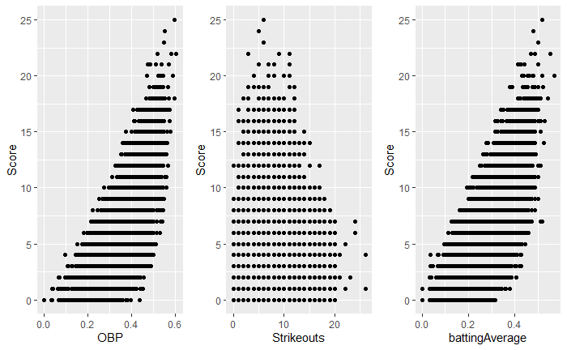

```r
p1 <- baseball_df %>% ggplot(aes(x=OBP,y=Score)) + geom_point()
p2 <- baseball_df %>% ggplot(aes(x=Strikeouts,y=Score)) + geom_point()
p3 <- baseball_df %>% ggplot(aes(x=battingAverage,y=Score)) + geom_point()
grid.arrange(p1,p2,p3,nrow=1)
```

```r
(with(baseball_df,cor(OBP,Score)))
```

```
[1] 0.75047
```

```r
(with(baseball_df,cor(Strikeouts,Score)))
```

```
[1] -0.1170105
```

```r
(with(baseball_df,cor(battingAverage,Score)))
```

```
[1] 0.7474769
```

```r
train_ids <- createDataPartition(baseball_df$Score,p=0.80,list = F)
baseball_train <- baseball_df[train_ids, ]
baseball_test <- baseball_df[-train_ids, ]

baseball_lm <- lm(Score ~ . - teamAbbr - League - RBI - OPS,data=baseball_train)

tidy(baseball_lm)
```

| term | estimate | std.error | statistic | p.value |
| --- | --- | --- | --- | --- |
| (Intercept) | -1.105809e+01 | 0.175260882 | -63.09501253 | 0.000000e+00 |
| isHomeTeam | 1.119439e+00 | 0.014596021 | 76.69483092 | 0.000000e+00 |
| atBats | 3.153029e-01 | 0.005240289 | 60.16899169 | 0.000000e+00 |
| Hits | 7.332567e-01 | 0.016261639 | 45.09119550 | 0.000000e+00 |
| Doubles | 2.243843e-01 | 0.014188425 | 15.81460526 | 3.866238e-56 |
| Triples | 4.326130e-01 | 0.029767531 | 14.53305038 | 1.031272e-47 |
| homeRuns | 5.543419e-01 | 0.041213034 | 13.45064536 | 3.864372e-41 |
| Walks | 5.111772e-01 | 0.007024398 | 72.77168112 | 0.000000e+00 |
| Strikeouts | 4.463038e-03 | 0.001864897 | 2.39318236 | 1.670818e-02 |
| LOB | -7.464505e-01 | 0.003651663 | -204.41383572 | 0.000000e+00 |

[output cut: 17 more lines]

The output from tidy tells us a lot about the predictions for the slope values for each variable in the dataset. Many of the slope estimates are very small or ar close to 0 with extremely small p values. Many of these p values are 0 which jumps out at me because that’s usually never seen and I don’t know how to interpret it. One estimate that confuses me is for battingAverage because it is negative. I’m pretty sure that BA and Score have a positive relationship as evidenced by the tree way graph I made earlier.

To get an idea how well suited the linear model is for the data, let’s plot the residuals vs fitted values:

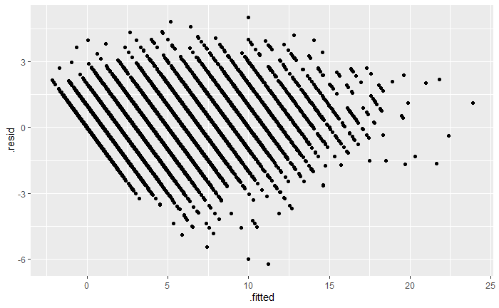

```r
augment(baseball_lm,data=baseball_train) %>% ggplot(aes(x=.fitted,y=.resid)) + geom_point()
```

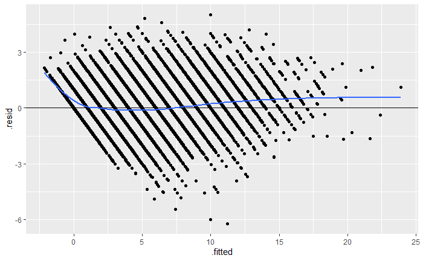

```r
augment(baseball_lm,data=baseball_train) %>%
  ggplot(aes(x=.fitted,y=.resid)) +
  geom_point() +
  geom_hline(yintercept = 0) +
  geom_smooth(se=FALSE)
```

The graph is rather linear except on values near both ends of the graph. However it is linear enough that we can say that linear regression is plausible to use on this data. However, better models will probably be used in the future.

### **Feature Selection Using Backward AIC**

Let’s get a summary of the information contained in our linear model:

```r
summary(baseball_lm)
```

```
Call:
lm(formula = Score ~ . - teamAbbr - League - RBI - OPS, data = baseball_train)

Residuals:
    Min      1Q  Median      3Q     Max
-6.2138 -0.5922 -0.0215  0.5769  5.0129

Coefficients:
                 Estimate Std. Error  t value Pr(>|t|)
(Intercept)    -1.106e+01  1.753e-01  -63.095   <2e-16 ***
isHomeTeam      1.119e+00  1.460e-02   76.695   <2e-16 ***
atBats          3.153e-01  5.240e-03   60.169   <2e-16 ***
Hits            7.333e-01  1.626e-02   45.091   <2e-16 ***
Doubles         2.244e-01  1.419e-02   15.815   <2e-16 ***
Triples         4.326e-01  2.977e-02   14.533   <2e-16 ***
homeRuns        5.543e-01  4.121e-02   13.451   <2e-16 ***
Walks           5.112e-01  7.024e-03   72.772   <2e-16 ***
Strikeouts      4.463e-03  1.865e-03    2.393   0.0167 *
LOB            -7.465e-01  3.652e-03 -204.414   <2e-16 ***
pitchersUsed   -1.222e-02  4.761e-03   -2.566   0.0103 *
indER           4.267e-02  4.265e-02    1.000   0.3171
teamER          1.016e-02  4.251e-02    0.239   0.8111
Errors          7.772e-02  6.699e-03   11.602   <2e-16 ***
battingAverage -2.089e+01  9.423e-01  -22.169   <2e-16 ***
OBP             1.692e+01  3.778e-01   44.794   <2e-16 ***
Slugging       -4.087e+00  4.749e-01   -8.606   <2e-16 ***
Win             1.778e+00  1.688e-02  105.309   <2e-16 ***
wonPrev         4.940e-03  1.012e-02    0.488   0.6255
WHIP            4.984e+00  8.817e-02   56.530   <2e-16 ***
KPercent        1.523e+01  3.720e-01   40.947   <2e-16 ***
BBPercent      -2.180e+01  4.292e-01  -50.781   <2e-16 ***
FIP             9.731e-02  5.320e-03   18.289   <2e-16 ***
BABIP           5.253e+00  2.129e-01   24.675   <2e-16 ***
ERA             4.234e-04  7.433e-03    0.057   0.9546
HAllowed       -6.746e-01  1.109e-02  -60.833   <2e-16 ***
defensiveSO    -4.474e-01  9.839e-03  -45.469   <2e-16 ***
---
Signif. codes:  0 ‘***’ 0.001 ‘**’ 0.01 ‘*’ 0.05 ‘.’ 0.1 ‘ ’ 1

Residual standard error: 0.9366 on 34934 degrees of freedom
Multiple R-squared:  0.9069,    Adjusted R-squared:  0.9068
F-statistic: 1.309e+04 on 26 and 34934 DF,  p-value: < 2.2e-16
```

One major thing we can see from this chart is that a large majority of the variables in the dataset are significant in some way. To know for sure we should run backwards AIC selection on our dataset to get the best set of features for our model.

```r
(baseball_selection <- ols_step_backward_aic(baseball_lm))
```

```
                        Backward Elimination Summary
--------------------------------------------------------------------------
Variable         AIC          RSS         Sum Sq       R-Sq      Adj. R-Sq
--------------------------------------------------------------------------
Full Model    94663.833    30644.475    298487.067    0.90689      0.90682
ERA           94661.836    30644.478    298487.064    0.90689      0.90683
teamER        94659.893    30644.528    298487.013    0.90689      0.90683
wonPrev       94658.130    30644.735    298486.806    0.90689      0.90683
--------------------------------------------------------------------------
```

The results from backwards selection confirm our statements for the output from summary. Now we are certain that teamER is not a good predictor of score and will be removed in the model. It seems that a linear model can accurately explain most of the dataset and will most likely be used going forward.

### **Cross-Validation**

First let’s get the training error to get a benchmark RMSE value

```r
baseball_fit_train <- lm(Score ~ . - teamAbbr - League - RBI - OPS,data=baseball_train)
baseball_fit_aug <- augment(baseball_fit_train,data=baseball_train)
sqrt(sum(baseball_fit_aug$.resid^2)/length(baseball_fit_aug$.resid))
```

```
[1] 0.9362335
```

```r
tC <- trainControl(method="repeatedcv",number=10,repeats = 5)
baseball_train_lm <- train(Score ~ . - teamAbbr - League - RBI - OPS,data=baseball_train,method="lm",trControl=tC)

baseball_train_lm$results
```

|  | intercept | RMSE | Rsquared | MAE | RMSESD | RsquaredSD | MAESD |
| --- | --- | --- | --- | --- | --- | --- | --- |
| 1 | TRUE | 0.9370976 | 0.9067436 | 0.7235879 | 0.01102977 | 0.0027038 | 0.008939902 |

Now that we have the estimate for RMSE let’s try to use the test data to get the actual test RMSE value. We will then compare it it with the cross-validated value.

```r
pred_vals <- predict(baseball_fit_train,baseball_test)

(test_rmse <- RMSE(pred_vals,baseball_test$Score))
```

```
[1] 0.9443588
```